# Chapter10_Lab1

# Goal

The goal of this lab is to construct a sequence and perform some simple analysis of the sequence.

For the purpose of sequence analysis, we will use the `TraMineR` library. Therefore, we will load this library first.

```r
options(repos = c(CRAN = "http://cran.rstudio.com"))
#install.packages("TraMineR", dependencies = TRUE)
library("TraMineR")
playerData <- read.table("Dota_Segmented.csv", header=TRUE, sep=",")

#disoplaying the first 20 rows in the data
playerData[1:20,]
```

|  | playersessionid | profileid | segment | op_num.1 | op_num.2 | op_num.3 | op_num.4 | op_num.5 | op_num.6 | op_num.7 | op_num.8 | op_num.9 | op_num.10 | op_num.11 | op_num.12 | op_num.13 | op_num.14 | op_num.15 | op_num.16 | op_num.17 | op_num.18 | op_num.19 | op_num.20 | op_num.21 | op_num.22 | op_num.23 | op_num.24 | op_num.25 | op_num.26 | … |
| --- | --- | --- | --- | --- | --- | --- | --- | --- | --- | --- | --- | --- | --- | --- | --- | --- | --- | --- | --- | --- | --- | --- | --- | --- | --- | --- | --- | --- | --- | --- |
| 1 | herodisruptor_2500916535_2 | herodisruptor_2500916535_2 | early_game | solo | solo | solo | solo | solo | solo | solo | fight | solo | solo | solo | solo | kill_hero | solo | solo | solo | solo | solo | solo |  |  |  |  |  |  |  | … |
| 2 | herodisruptor_2500916535_2 | herodisruptor_2500916535_2 | mid_game | solo | solo | solo | solo | solo | solo | teaming | solo | teaming | teaming | teaming | death | fight | solo | solo | death | fight | solo | solo |  |  |  |  |  |  |  | … |
| 3 | herodisruptor_2500916535_2 | herodisruptor_2500916535_2 | late_game | death | harrassed_by_opponents | fight_diminishes | solo | solo | solo | solo | solo | solo | solo | solo | solo |  |  |  |  |  |  |  |  |  |  |  |  |  |  | … |
| 4 | herorubick_2500811393_3 | herorubick_2500811393_3 | early_game | solo | solo | solo | solo | kill_hero | teaming | teaming | solo | solo | death | kill_hero | solo | solo | solo | solo | solo | solo | solo | death | solo | solo | solo | death | solo | solo | solo | … |
| 5 | herorubick_2500811393_3 | herorubick_2500811393_3 | mid_game | solo | solo | solo | solo | teaming | teaming | solo | solo | solo | solo | death | harrassed_by_opponents | fight_diminishes | solo | teaming | teaming | death | solo | solo | solo | solo | solo | solo | death | solo | solo | … |
| 6 | herorubick_2500811393_3 | herorubick_2500811393_3 | late_game | death | death | teaming | teaming | solo | solo | teaming | solo | solo | solo | teaming | teaming | death | harrassed_by_opponents | fight_diminishes | solo | solo | solo | solo | solo | solo | solo | solo | solo | solo |  | … |
| 7 | herosven_2501342105_3 | herosven_2501342105_3 | early_game | solo | solo | solo | solo | solo | solo | solo | kill_hero | solo | fight | solo | fight |  |  |  |  |  |  |  |  |  |  |  |  |  |  | … |
| 8 | herosven_2501342105_3 | herosven_2501342105_3 | mid_game | solo | solo | solo | solo | solo | solo | solo | solo | solo | solo | solo | teaming | solo | solo | solo | death | fight | solo | solo | solo | kill_hero | solo | solo | solo | solo | kill_hero | … |
| 9 | herosven_2501342105_3 | herosven_2501342105_3 | late_game | kill_hero | death | fight | solo | solo | solo | teaming | solo | solo | teaming | teaming | teaming | kill_hero | fight | solo | solo | kill_hero | teaming | solo | solo | teaming | solo | solo | kill_hero | fight | teaming | … |
| 10 | heroemberspirit_2501098786_3 | heroemberspirit_2501098786_3 | early_game | teaming | solo | solo | solo | solo | solo | solo | fight | solo | solo | solo | solo | solo | solo | solo | solo | solo | kill_hero | fight | fight | kill_hero | solo | fight | solo | solo | solo | … |

[output cut: 10 more lines]

# Building the Sequence Structure

We create a sequence using the `Seqdef` function. This function takes in (a) an alphabet, spelling out the different actions in the sequence, (b) the data for the sequence, (c) the colors and (d) labels for each sequence, which can be the same as the alphabet.

```r
#in order to create a sequence, we need to create alphabet for the #sequence. For purposes of plotting, we need colors that are unique #for each alphabet.
playerData.labels <- c("solo",
                       "fight",
                       "kill_hero",
                       "teaming",
                       "death",
                       "harrassed_by_opponents",
                       "fight_diminishes",
                       "fight_intensifies",
                       "team_fight",
                       "full_team_assembly",
                       "",
                       " ")
playerData.scode <- c("solo",
                      "fight",
                      "kill_hero",
                      "teaming",
                      "death",
                      "harrassed_by_opponents",
                      "fight_diminishes",
                      "fight_intensifies",
                      "team_fight",
                      "full_team_assembly",
                      " ")
playData.colors <-
  c("purple", "green", "black", "yellow", "red", "orange",
    "cyan", "pink", "gray", "blue", "white")


playerData.seq <- seqdef(playerData, 4:95, alphabet = playerData.labels,states=playerData.scode, labels = playerData.scode,xstep=6, cpal = playData.colors)
```

```
##  [>] found missing values ('NA') in sequence data
```

```
##  [>] preparing 550 sequences
```

```
##  [>] coding void elements with '%' and missing values with '*'
```

```
##  [>] state coding:
```

```
##        [alphabet]             [label]                [long label]
```

```
##      1  solo                   solo                   solo
```

```
##      2  fight                  fight                  fight
```

```
##      3  kill_hero              kill_hero              kill_hero
```

```
##      4  teaming                teaming                teaming
```

```
##      5  death                  death                  death
```

```
##      6  harrassed_by_opponents harrassed_by_opponents harrassed_by_opponents
```

```
##      7  fight_diminishes       fight_diminishes       fight_diminishes
```

```
##      8  fight_intensifies      fight_intensifies      fight_intensifies
```

```
##      9  team_fight             team_fight             team_fight
```

```
##      10  full_team_assembly     full_team_assembly     full_team_assembly
```

```
##      11
```

```
##  [>] 550 sequences in the data set
```

```
##  [>] min/max sequence length: 7/92
```

The `seqdef` function creates a sequence data. As you see from the output, it has found several missing values in the sequences. In this dataset, we have sequences of different lengths which is then interpreted as missing values.

Once we have the sequence in the right structure it is then possible to use the library functions to inspect the sequences and explore the data.

# Exploratory Analysis of the Sequence

The first thing to do is to plot the sequences to see how they vary. For that we use the variations of the `seqplot` function. Below we have some code using these variations to show you the differences. Note that `seqlegend` function will create the legend that we will then use for all the other charts.

```
##  [!!] In rmarkdown::render() : fontsize is deprecated, use cex instead.
```

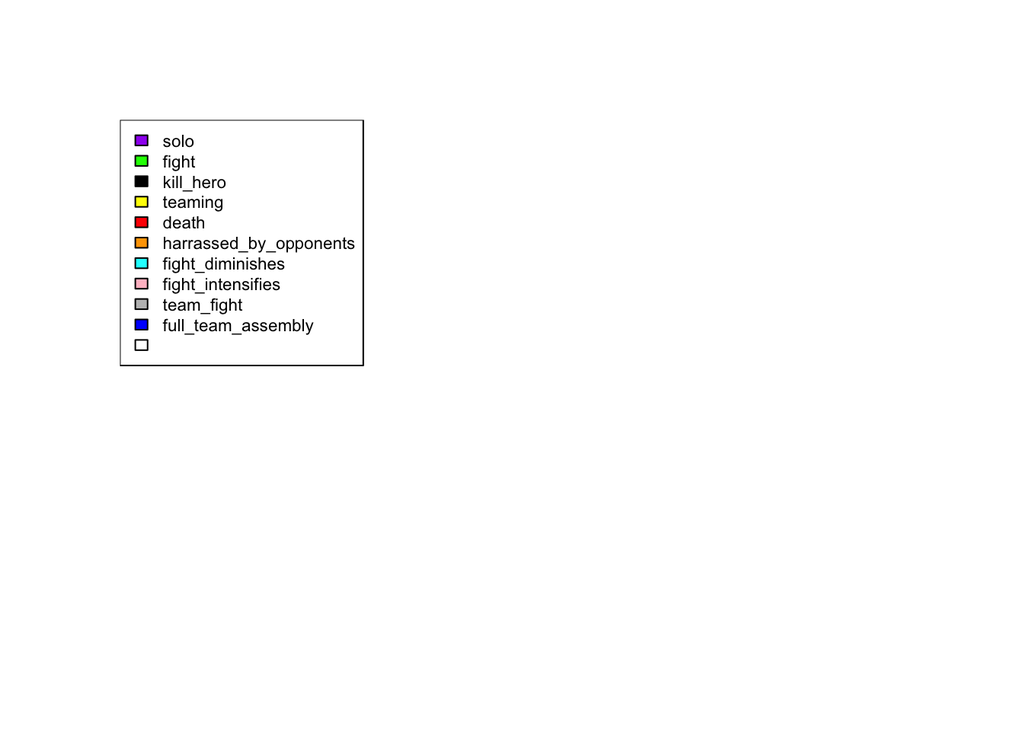

```r
#create a legend for the data that will be plotted in the charts below.
seqlegend(playerData.seq, fontsize = .7)
```

```
##  [!!] In rmarkdown::render() : title is deprecated, use main instead.
```

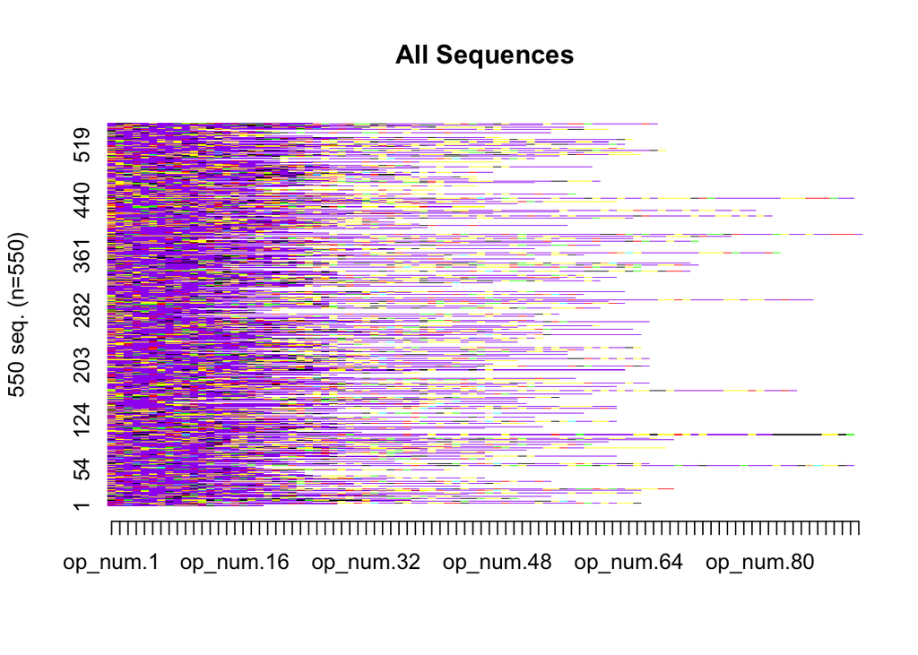

```r
#displays all sequences in the data
seqIplot(playerData.seq, border = NA, title = "All Sequences", with.legend ="FALSE",
         missing.color = "#FFFFFF")
```

```
##  [!!] In rmarkdown::render() : title is deprecated, use main instead.
```

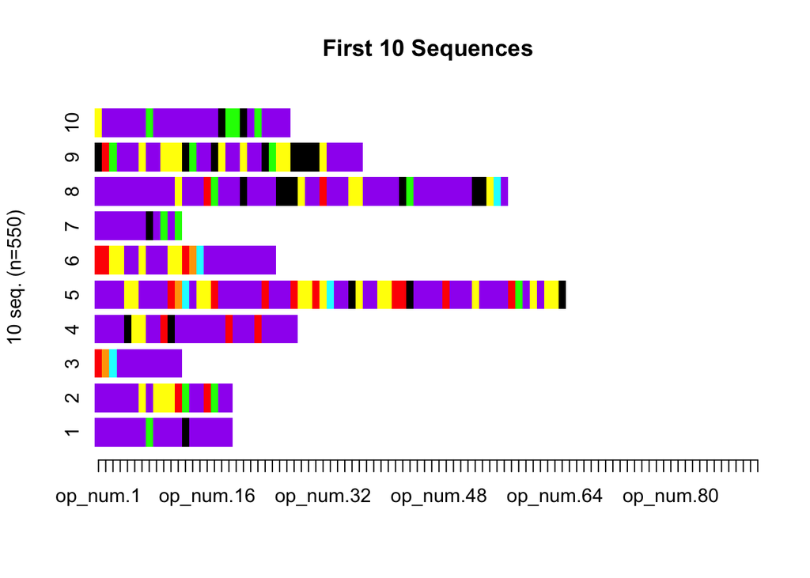

```r
#displays only the first 10 sequences
seqiplot(playerData.seq, border = NA, title = "First 10 Sequences", with.legend ="FALSE",
         missing.color = "#FFFFFF")
```

```
##  [!!] In rmarkdown::render() : title is deprecated, use main instead.
```

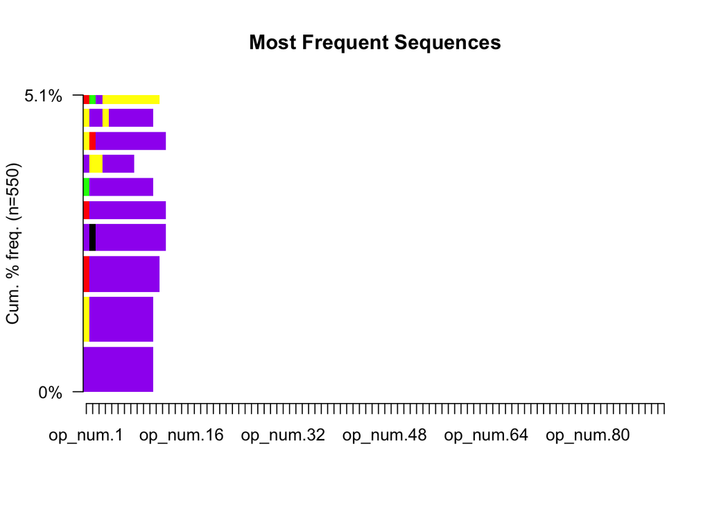

```r
#plots the most frequence sequences
seqfplot(playerData.seq, border = NA, title = "Most Frequent Sequences", with.legend ="FALSE",
         missing.color = "#FFFFFF")
```

```
##  [!!] In rmarkdown::render() : title is deprecated, use main instead.
```

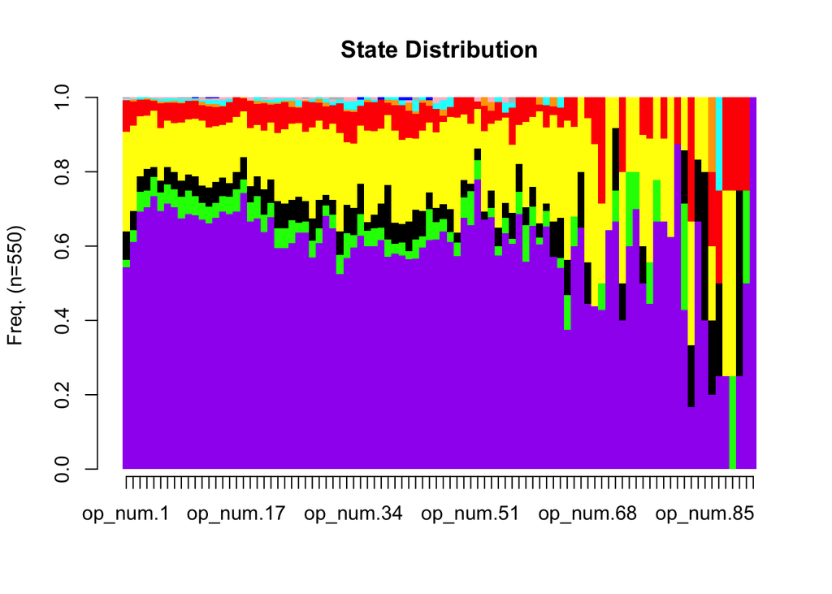

```r
# Plots the state distribution by time points
seqdplot(playerData.seq, border = NA, title = "State Distribution", with.legend ="FALSE",
         missing.color = "FFFFFF")
```

You can also group these sequences by segment of play, so you can compare the frequent sequences per loction/level or game segment.

```
##  [!!] In rmarkdown::render() : fontsize is deprecated, use cex instead.
```

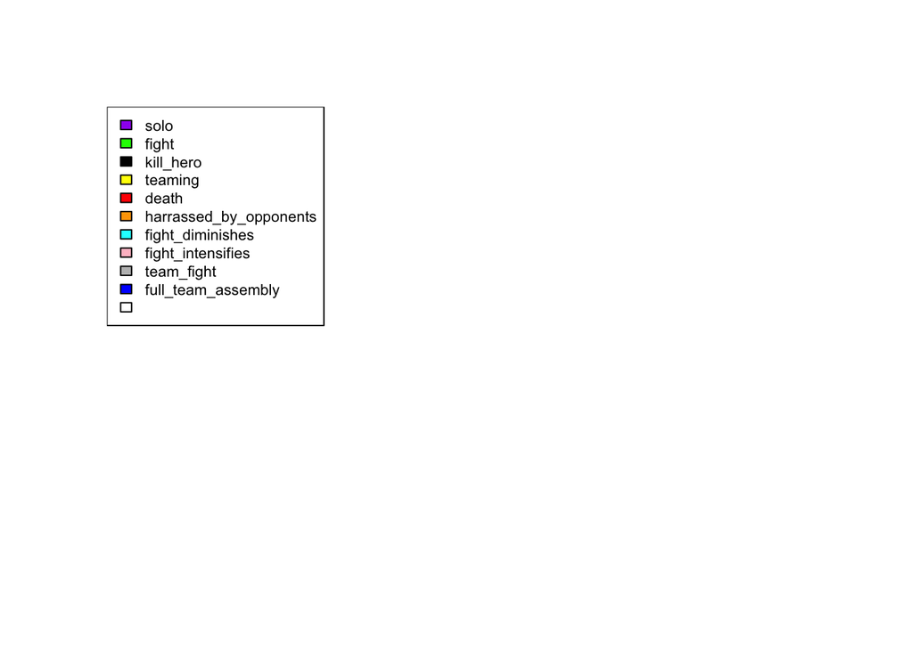

```r
#create a legend for the data charts below
seqlegend(playerData.seq, fontsize = .7)
```

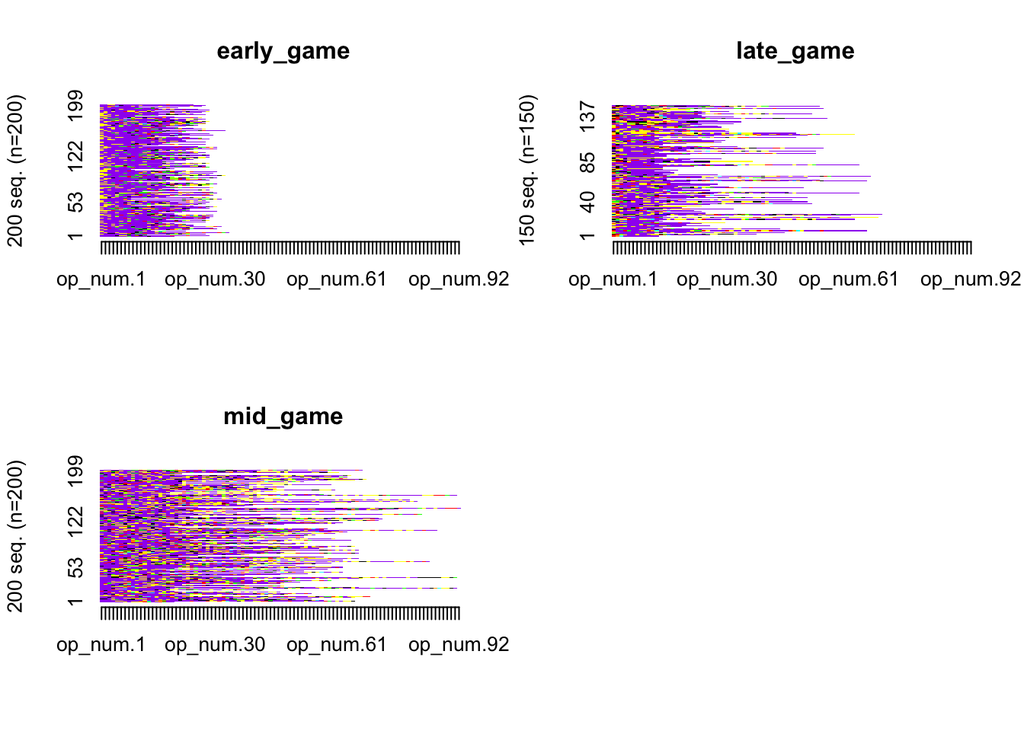

```r
#displays all sequences in the data
seqIplot(playerData.seq, group=playerData$segment, border = NA, with.legend ="FALSE", missing.color = "#FFFFFF")
```

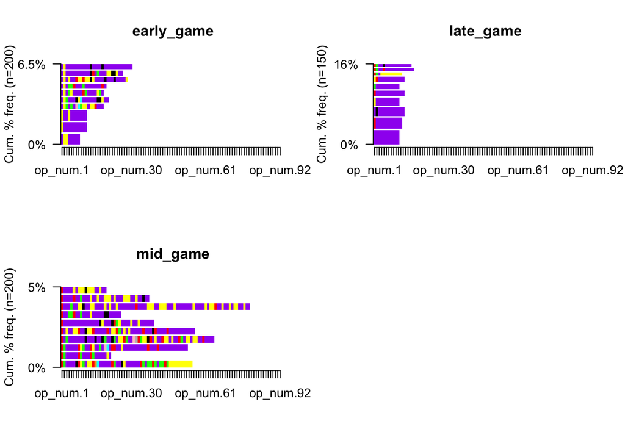

```r
#plots the most frequence sequences
seqfplot(playerData.seq, group=playerData$segment, border = NA, with.legend ="FALSE", missing.color = "#FFFFFF")
```

# Frequencies of a state occupying a specific position

As discussed in the Chapter, another interesting function to use is the `seqstatd`, which tells us what the frequencies are of a state occupying a specific position or time slot. For example, Solo seems to have a very high probability of occupying any of the timeslots. However, one can imagine some actions may have more probability later in the game than earlier, for example.

```r
seqstatd(playerData.seq)
```

```
##                                             [State frequencies]
##                        op_num.1 op_num.2 op_num.3 op_num.4 op_num.5 op_num.6
## solo                     0.5436   0.6109   0.6927   0.7036   0.7345   0.6945
## fight                    0.0200   0.0327   0.0527   0.0455   0.0509   0.0491
## kill_hero                0.0764   0.0509   0.0418   0.0582   0.0273   0.0327
## teaming                  0.2673   0.2291   0.1618   0.1436   0.1509   0.1418
## death                    0.0855   0.0655   0.0455   0.0436   0.0273   0.0655
## harrassed_by_opponents   0.0000   0.0055   0.0000   0.0036   0.0036   0.0055
## fight_diminishes         0.0018   0.0018   0.0055   0.0018   0.0036   0.0073
## fight_intensifies        0.0036   0.0036   0.0000   0.0000   0.0018   0.0036
## team_fight               0.0018   0.0000   0.0000   0.0000   0.0000   0.0000
## full_team_assembly       0.0000   0.0000   0.0000   0.0000   0.0000   0.0000
##                          0.0000   0.0000   0.0000   0.0000   0.0000   0.0000
##                        op_num.7 op_num.8 op_num.9 op_num.10 op_num.11 op_num.12
## solo                     0.7145   0.7049   0.6746    0.6858    0.6834    0.6705
## fight                    0.0509   0.0474   0.0588    0.0628    0.0503    0.0460
## kill_hero                0.0473   0.0474   0.0423    0.0444    0.0540    0.0460
## teaming                  0.1255   0.1311   0.1562    0.1479    0.1546    0.1743
## death                    0.0473   0.0546   0.0515    0.0499    0.0484    0.0421
## harrassed_by_opponents   0.0036   0.0055   0.0037    0.0000    0.0019    0.0077
## fight_diminishes         0.0091   0.0073   0.0092    0.0055    0.0037    0.0057
## fight_intensifies        0.0018   0.0018   0.0018    0.0018    0.0019    0.0057
## team_fight               0.0000   0.0000   0.0018    0.0018    0.0000    0.0019
## full_team_assembly       0.0000   0.0000   0.0000    0.0000    0.0019    0.0000
##                          0.0000   0.0000   0.0000    0.0000    0.0000    0.0000
##                        op_num.13 op_num.14 op_num.15 op_num.16 op_num.17
## solo                      0.6608    0.6761    0.6934    0.6857     0.692
## fight                     0.0451    0.0405    0.0412    0.0464     0.061
## kill_hero                 0.0510    0.0567    0.0494    0.0380     0.046
## teaming                   0.1627    0.1498    0.1420    0.1624     0.148
## death                     0.0569    0.0506    0.0494    0.0549     0.052
## harrassed_by_opponents    0.0059    0.0081    0.0021    0.0000     0.000
## fight_diminishes          0.0098    0.0101    0.0144    0.0084     0.000
## fight_intensifies         0.0020    0.0061    0.0082    0.0042     0.000
## team_fight                0.0039    0.0000    0.0000    0.0000     0.000
## full_team_assembly        0.0020    0.0020    0.0000    0.0000     0.000
##                           0.0000    0.0000    0.0000    0.0000     0.000
##                        op_num.18 op_num.19 op_num.20 op_num.21 op_num.22
## solo                      0.7427    0.6667    0.6750    0.6371    0.6785
## fight                     0.0361    0.0516    0.0600    0.0470    0.0381
```

[output cut: 238 more lines]

```
## H                            0.4      0.44      0.47      0.46       0.5
##                        op_num.58 op_num.59 op_num.60 op_num.61 op_num.62
## H                           0.44      0.51      0.44      0.42      0.44
##                        op_num.63 op_num.64 op_num.65 op_num.66 op_num.67
## H                           0.45      0.53      0.56      0.44      0.37
##                        op_num.68 op_num.69 op_num.70 op_num.71 op_num.72
## H                           0.47      0.41      0.52      0.27      0.41
##                        op_num.73 op_num.74 op_num.75 op_num.76 op_num.77
## H                           0.53       0.4      0.33      0.49      0.51
##                        op_num.78 op_num.79 op_num.80 op_num.81 op_num.82
## H                           0.35      0.35      0.28      0.16      0.53
##                        op_num.83 op_num.84 op_num.85 op_num.86 op_num.87
## H                           0.55      0.36      0.44      0.67      0.58
##                        op_num.88 op_num.89 op_num.90 op_num.91 op_num.92
## H                           0.43      0.43      0.43      0.43         0
```

# Transition Probabilities

As discussed in the Chapter, another element that would be interesting to explore is the probability of transitioning from one state to another. This can be explore through the function `seqtrate`.

```r
playerData.trate <- seqtrate(playerData.seq)
```

```
##  [>] computing transition probabilities for states solo/fight/kill_hero/teaming/death/harrassed_by_opponents/fight_diminishes/fight_intensifies/team_fight/full_team_assembly/  ...
```

```r
round(playerData.trate, 2)
```

```
##                             [-> solo] [-> fight] [-> kill_hero] [-> teaming]
## [solo ->]                        0.77       0.03           0.04         0.12
## [fight ->]                       0.53       0.19           0.06         0.12
## [kill_hero ->]                   0.33       0.08           0.18         0.26
## [teaming ->]                     0.43       0.02           0.07         0.39
## [death ->]                       0.55       0.21           0.02         0.13
## [harrassed_by_opponents ->]      0.00       0.01           0.05         0.01
## [fight_diminishes ->]            0.72       0.04           0.00         0.23
## [fight_intensifies ->]           0.00       0.10           0.00         0.14
## [team_fight ->]                  0.00       0.00           0.08         0.00
## [full_team_assembly ->]          0.25       0.00           0.25         0.25
## [  ->]                           0.00       0.00           0.00         0.00
##                             [-> death] [-> harrassed_by_opponents]
## [solo ->]                         0.04                        0.00
## [fight ->]                        0.09                        0.00
## [kill_hero ->]                    0.13                        0.01
## [teaming ->]                      0.08                        0.00
## [death ->]                        0.04                        0.05
## [harrassed_by_opponents ->]       0.07                        0.08
## [fight_diminishes ->]             0.00                        0.00
## [fight_intensifies ->]            0.00                        0.08
## [team_fight ->]                   0.17                        0.00
## [full_team_assembly ->]           0.00                        0.00
## [  ->]                            0.00                        0.00
##                             [-> fight_diminishes] [-> fight_intensifies]
## [solo ->]                                    0.00                   0.00
## [fight ->]                                   0.00                   0.00
## [kill_hero ->]                               0.00                   0.00
## [teaming ->]                                 0.01                   0.01
## [death ->]                                   0.00                   0.00
## [harrassed_by_opponents ->]                  0.77                   0.00
## [fight_diminishes ->]                        0.00                   0.01
## [fight_intensifies ->]                       0.61                   0.00
## [team_fight ->]                              0.75                   0.00
## [full_team_assembly ->]                      0.00                   0.00
## [  ->]                                       0.00                   0.00
##                             [-> team_fight] [-> full_team_assembly] [->  ]
## [solo ->]                              0.00                    0.00      0
## [fight ->]                             0.00                    0.00      0
## [kill_hero ->]                         0.00                    0.00      0
## [teaming ->]                           0.00                    0.00      0
## [death ->]                             0.00                    0.00      0
## [harrassed_by_opponents ->]            0.00                    0.00      0
## [fight_diminishes ->]                  0.00                    0.00      0
## [fight_intensifies ->]                 0.08                    0.00      0
## [team_fight ->]                        0.00                    0.00      0
## [full_team_assembly ->]                0.00                    0.25      0
## [  ->]                                 0.00                    0.00      0
```

# Shannon Entropy

A measure also discussed in Chapter 10 as well as other earlier Chapters in the book is the measure of entropy, which gives us a measure of how diverse the states are at a given position. We can use this package, specifically the to do this we will use the `seqHplot` function to display this.

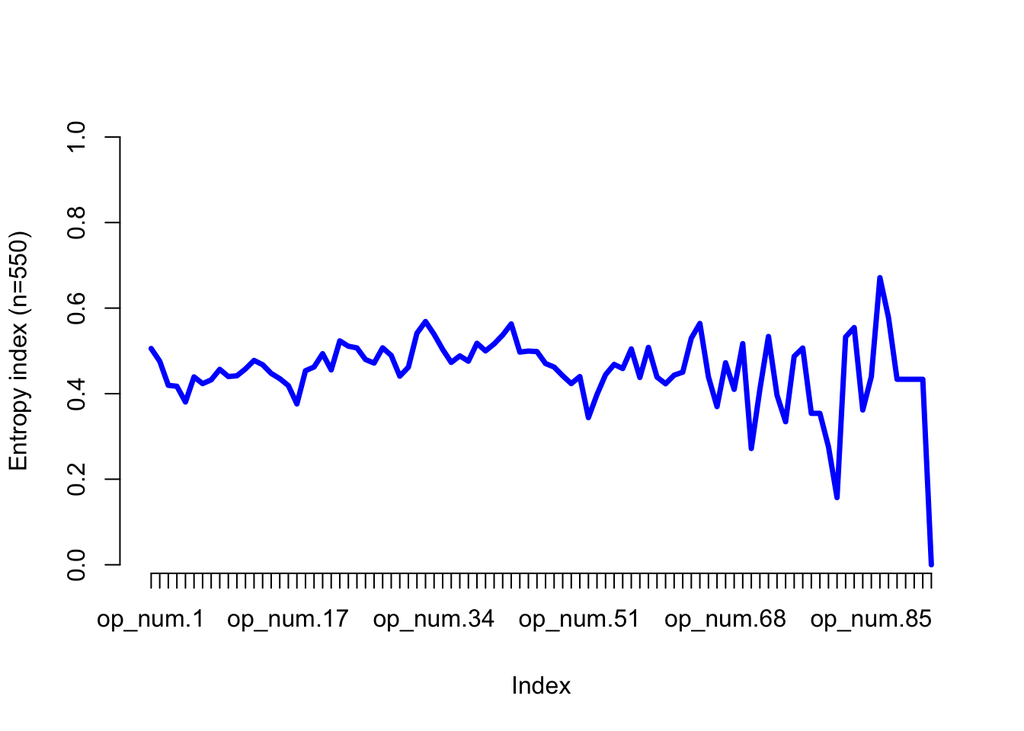

```r
#Shannon Entropy for the entire data set
seqHtplot(playerData.seq)
```

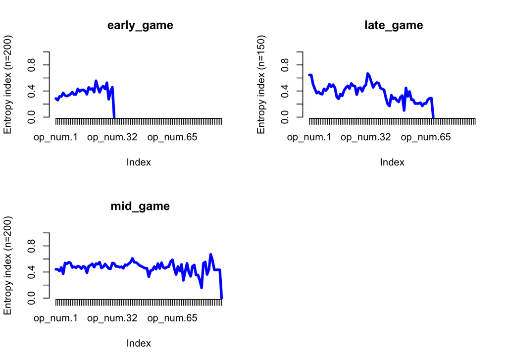

```r
#Shannon Entropy per game segment
seqHtplot(playerData.seq, group=playerData$segment)
```